# 02_tratamento_dados

2025-04-28

### 📄 Sobre os Dados

Permissões e Uso: Todos os dados do Climate TRACE estão disponíveis gratuitamente sob a Licença Pública Internacional Creative Commons Atribuição 4.0, salvo indicação em contrário.

Forma sugerida de citação: Para fontes de diferentes setores ou dados globais acessados e baixados, utilize a seguinte citação: Climate TRACE (2025). Climate TRACE Emissions Inventory v4.2.0. Disponível em: https://climatetrace.org. Acessado em: **28/04/2025**.

Para citações específicas por setor, consulte a seção correspondente na plataforma.

### 📁 Arquivos Disponíveis

A seguir, uma breve descrição dos arquivos incluídos no pacote de dados baixado da plataforma Climate TRACE:

- `detailed_data_schema.csv` - Arquivo com o mapeamento e a explicação do significado de cada coluna dos dados para todos os diferentes subsetores.
- `<nome-do-subsetor>_emissions_sources.csv` - Contém os dados de emissões no nível de fonte de emissão para todos os subsetores monitorados pela Climate TRACE.
- `<nome-do-subsetor>_country_emissions.csv` - Contém os dados de emissões no nível de país para todos os subsetores monitorados pela Climate TRACE.
- `<nome-do-subsetor>_emissions_sources_confidence.csv` - Arquivo que especifica a classificação de confiança dos dados reportados pelas fontes de emissão, referenciando o arquivo _emissions_sources.csv.
- `<nome-do-subsetor>_emissions_sources_ownership.csv` - Contém informações sobre a propriedade das fontes de emissão listadas no arquivo `<subsetor>_emissions_sources.csv.`

🔗 Observação: A lista completa de setores de emissão para os quais a Climate TRACE fornece dados está disponível no site: https://climatetrace.org/sectors.

Para alguns setores, há dados geoespaciais adicionais não incluídos neste pacote de download. Para solicitá-los, entre em contato pelo e-mail: coalition@climatetrace.org.

### 📄 Sobre os Dados

Para mais informações sobre a origem, metodologia e estrutura dos dados utilizados, acesse o documento oficial disponibilizado pela Climate TRACE:

### 📥 Clique aqui para baixar o arquivo about_the_data.pdf e about_the_data_v4_2_0.pdf

### 🔍📁 Encontrando os arquivos `.csv`

Esses arquivos contêm as estimativas anuais/mensais de emissões e remoções de CO₂ organizadas por município, subsetor e etc.

```r
emissions_sources_files <- list.files("../data-raw/",
             full.names = TRUE,
             recursive = TRUE,
           pattern = "emissions_sources_v4_2_0.csv")
```

### 🛠️ Criando função para ler $1$ arquivo

```r
my_file_read <- function(file_path) {
  read.csv(file_path,
           stringsAsFactors = FALSE)  |>
    # dplyr::select(!dplyr::starts_with("other")) |>
    dplyr::mutate(dplyr::across(dplyr::starts_with("other"),as.character)) |>
    dplyr::mutate(
      directory = file_path,
      native_source_id = as.character(native_source_id))
}
```

### 🧩 Aplicando a função de leitura aos arquivos

`emissions_sources_files`: contém os caminhos completos dos arquivos .csv que queremos importar (obtidos com list.files()).

`my_file_read`: é a função definida anteriormente que realiza a leitura e pequenas transformações no arquivo.

`map_dfr()`: aplica a função a cada arquivo da lista e junta tudo em um único data.frame. `map` vem do conceito de programação funcional chamado “mapear uma função sobre uma estrutura de dados”. Isso significa: **Aplicar uma função a cada elemento de um vetor ou lista, retornando uma nova estrutura com os resultados**.

`glimpse()`: mostra um resumo estruturado dos dados finais.

```r
# Empilhando todos os arquivos no objeto dados, pela Aplicanção
# da função a todos os arquivos encontrados
dados_emissoes <- purrr::map_dfr(
  emissions_sources_files,
  my_file_read)
```

### 🛠️ Tratamento (preprocessing/transformation):

Agora precisamos converter tipos de dados (como de character para Date), criar novas variáveis (como o year a partir de end_time) e reorganizar ou transformar variáveis para análise.

**Correções nominais**

Criamos uma tabela de correções para padronizar nomes de localidades com acentuação incorreta ou variações de grafia observadas nos dados originais.

```r
correcoes <- c(
  "Itapoa" = "Itapoá",
  "Maraba" = "Marabá",
  "Ribeirao" = "Ribeirão",
  "Sao Goncalo" = "São Gonçalo",
  "Sao Jose" = "São José",
  "Ribeirao" = "Ribeirão",
  "Ceilândia" = "Brasília",
  "Gama" = "Brasília",
  "Itapoã" = "Brasília",
  "Icaivera" = "Betim",
  "Taquaralto" = "Palmas",
  "São João del-Rei" = "São João del Rei"
)
```

**Tratamento de nomes e tipos de fonte**

Aplicou-se a tabela de correções aos nomes das fontes emissoras (`source_name`) e foram atribuídos os tipos de fonte (`source_type`) quando ausentes, com base em padrões contidos nos nomes originais. Além disso, foi criada uma nova coluna com o nome da fonte tratado (`source_name_trat`), removendo os sufixos descritivos como `"Municipality"` e `"Urban Area"`. Em adição a coluna `directory`, que armazena o caminho dos arquivos originais, foi tratada para remover trechos desnecessários, mantendo apenas a estrutura hierárquica útil à análise. Por fim, as colunas foram reorganizadas para facilitar a visualização e manuseio dos dados, colocando identificadores e nomes das fontes no início da tabela.

```r
dados_emissoes <- dados_emissoes |>
  dplyr::mutate(
    start_time = lubridate::as_date(start_time),
    end_time = lubridate::as_date(end_time),
    created_date = lubridate::as_date(created_date),
    modified_date = lubridate::as_date(modified_date),
    year = lubridate::year(end_time),
    month = lubridate::month(end_time),
    source_name = stringr::str_replace_all(source_name, correcoes),
    source_type = ifelse(is.na(source_type),
                         ifelse(stringr::str_detect(source_name,"Municipality"),
                                "Municipality",          ifelse(stringr::str_detect(source_name,"Urban Area"),"Urban Area",NA)),source_type),source_name_trat = stringr::str_remove(source_name,
  " Municipality| Urban Area"),
    directory = stringr::str_remove(
      directory,"../data-raw/BRA/DATA/|_emissions_sources_v4_2_0.csv"
    ),
  ) |>
  dplyr::relocate(source_id, source_name, source_name_trat)
dplyr::glimpse(dados_emissoes)
```

```
## Rows: 5,302,740
## Columns: 51
## $ source_id              <int> 10812934, 10812934, 10812934, 10812934, 1081293…
## $ source_name            <chr> "Abadia de Goiás Municipality", "Abadia de Goiá…
## $ source_name_trat       <chr> "Abadia de Goiás", "Abadia de Goiás", "Abadia d…
## $ source_type            <chr> "Municipality", "Municipality", "Municipality",…
## $ iso3_country           <chr> "BRA", "BRA", "BRA", "BRA", "BRA", "BRA", "BRA"…
## $ sector                 <chr> "agriculture", "agriculture", "agriculture", "a…
## $ subsector              <chr> "cropland-fires", "cropland-fires", "cropland-f…
## $ start_time             <date> 2021-01-01, 2021-02-01, 2021-03-01, 2021-04-01…
## $ end_time               <date> 2021-01-31, 2021-02-28, 2021-03-31, 2021-04-30…
## $ lat                    <dbl> -16.78557, -16.78557, -16.78557, -16.78557, -16…
## $ lon                    <dbl> -49.4521, -49.4521, -49.4521, -49.4521, -49.452…
## $ geometry_ref           <chr> "gadm_BRA.9.1_2", "gadm_BRA.9.1_2", "gadm_BRA.9…
## $ gas                    <chr> "co2e_100yr", "co2e_100yr", "co2e_100yr", "co2e…
```

[output cut: 38 more lines]

Devido à exitência de valores de coordenadas como valores `NA`, associados à fontes do tipo `"Urban Area"`, esse trecho de código realiza tratamento geoespacial, garantindo que cada fonte emissora do tipo `"Municipality"` esteja corretamente associada a uma coordenada geográfica (latitude e longitude). O objeto `dados_emissoes_municipality` é criado e será usado dentro das funções a seguir busca de coordenadas geográficas e substituição de `NAs`.

```r
dados_emissoes_municipality <-  dados_emissoes |>
  dplyr::filter(source_type == "Municipality") |>
  dplyr::group_by(source_name_trat,lat,lon) |>
  dplyr::summarise(
    lon = mean(lon, na.rm=TRUE),
    lat = mean(lat, na.rm=TRUE)
  ) |> dplyr::ungroup()
```

#### 🧩 Funções auxiliares para busca de coordenadas

As funções `get_lat(muni)` e `get_lon(muni)` recebem um nome de município tratado, usam esse nome para filtrar a tabela `dados_emissoes_municipality` e retornam, respectivamente, a latitude e longitude associadas. O uso de `slice(1)` garante que apenas o primeiro valor seja retornado, mesmo que haja múltiplos registros. Portanto, é uma função de busca para preencher valores faltantes de `lat` e `lon` no `dados_emissoes`.

```r
get_lat <- function(muni){
  muni <- muni[1]
  lat <- dados_emissoes_municipality |>
    dplyr::filter(source_name_trat == muni) |> dplyr::slice(1) |> dplyr::pull(lat)
  return(lat)
}

get_lon <- function(muni){
  muni <- muni[1]
  lon <- dados_emissoes_municipality |>
    dplyr::filter(source_name_trat == muni) |> dplyr::slice(1) |> dplyr::pull(lon)
  return(lon)
}
```

### 🔄 Atualização dos dados principais com coordenadas faltantes

Inicalmente agrupamos os dados por `source_name` (nome original da fonte emissora) para que a função retorne os valores de `lat` e `lon` para cada `source_name_trat`. Em cada grupo, verifica-se `lat` ou `lon` está ausente. Se estiver, busca o valor correspondente nas tabelas auxiliares, usando as funções criadas. Se não estiver ausente, mantém o valor original. Ao final, remove qualquer linha que ainda esteja sem `lat` (e, implicitamente, `lon`).

```r
dados_emissoes <- dados_emissoes |>
  dplyr::group_by(source_name) |>
  dplyr::mutate(
    lat=ifelse(is.na(lat),get_lat(source_name_trat),lat),
    lon=ifelse(is.na(lon),get_lon(source_name_trat),lon)
  ) |>
  dplyr::filter(!is.na(lat))
```

### 🌎 Carregando dados geográficos do Brasil

Nesta etapa, utilizamos o pacote `{geobr}` para importar informações geográficas oficiais do Brasil. Esses dados são importantes para análises espaciais e visualizações no contexto ambiental e territorial. Os seguintes objetos são criados:

- `municipality`: Contém os limites geográficos de todos os municípios brasileiros.
- `states`: Contém os limites geográficos de todos os estados brasileiros.
- `biomes`: Traz os contornos dos biomas do Brasil (como Amazônia, Cerrado, Mata Atlântica, etc.).
- `conservation`: Inclui os limites das Unidades de Conservação brasileiras, como parques nacionais e reservas ecológicas.
- `indigenous`: Contém as terras indígenas oficialmente reconhecidas.

Essas camadas podem ser sobrepostas a dados de emissões para entender a distribuição espacial em relação a áreas protegidas, territórios indígenas ou regiões ecológicas específicas.

Para maiores informações acesse [Introduction to geobr (R)](https://cran.r-project.org/web/packages/geobr/vignettes/intro_to_geobr.html)

```r
country_br <- geobr::read_country(showProgress = FALSE)
municipality <- geobr::read_municipality(showProgress = FALSE)|>
  dplyr::rename(target = name_muni )
states <- geobr::read_state(showProgress = FALSE) |>
  dplyr::rename(target = abbrev_state )
biomes <- geobr::read_biomes(showProgress = FALSE) |>
  dplyr::rename(target = name_biome)
conservation <- geobr::read_conservation_units(showProgress = FALSE) |>
  dplyr::rename(target = name_conservation_unit)
indigenous <- geobr::read_indigenous_land(showProgress = FALSE) |>
  dplyr::rename(target = terrai_nom)
```

### 🗺️ Plotando espacialmente os ponto

Nesta etapa, vamos representar os dados no espaço geográfico, gerando mapas que permitem visualizar a distribuição dos pontos de interesse. A plotagem espacial é fundamental para identificar padrões, áreas de maior concentração e possíveis anomalias nos dados.

Criando o mapa com sobreposição

Terras Indígenas reconhecidas

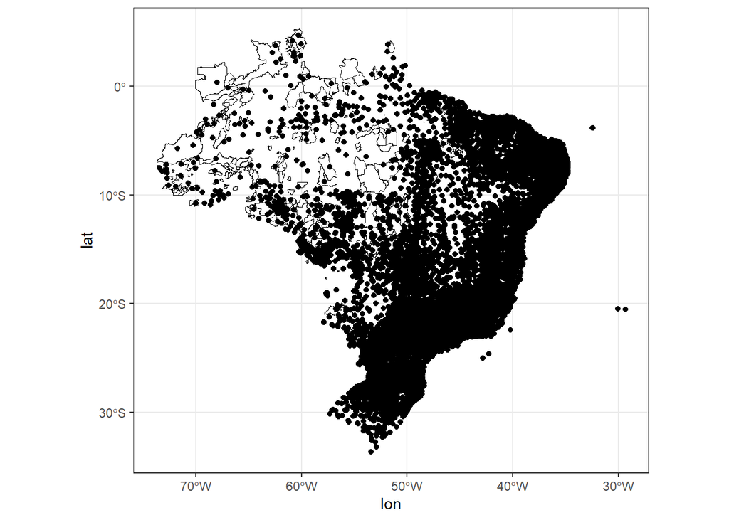

```r
indigenous    |>
  ggplot2::ggplot() +
  ggplot2::geom_sf(fill="white", color="black",
          size=.15, show.legend = FALSE) +
  ggplot2::geom_point(
    data = dados_emissoes  |>
      dplyr::filter(
        year == 2021),
     ggplot2::aes(lon,lat)) +
  ggplot2::theme_bw()
```

Áreas de conservação

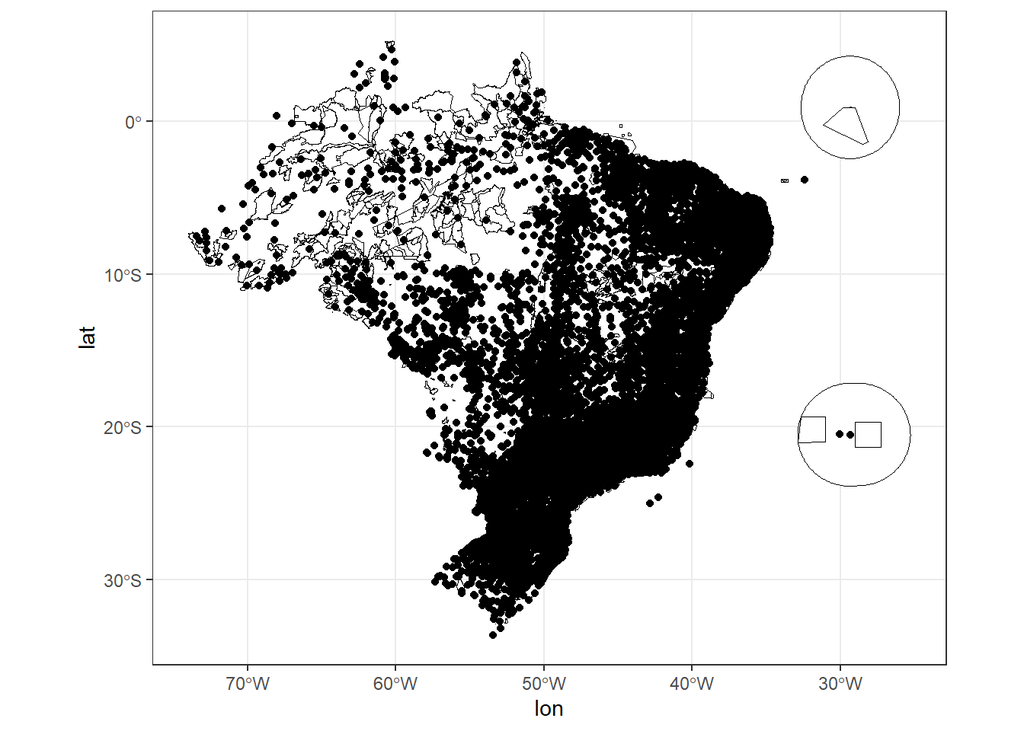

```r
conservation    |>
  ggplot2::ggplot() +
  ggplot2::geom_sf(fill="white", color="black",
          size=.15, show.legend = FALSE) +
  ggplot2::geom_point(
    data = dados_emissoes  |>
      dplyr::filter(
        year == 2021),
     ggplot2::aes(lon,lat)) +
  ggplot2::theme_bw()
```

### 🧭 Função para verificar se pontos estão dentro de um polígono

A função `def_pol()` tem como objetivo **verificar se pontos (definidos por coordenadas `x` e `y`) estão dentro de um polígono geográfico**.

Ela utiliza a função `point.in.polygon()` do pacote `{sp}` para realizar essa verificação espacial. Isso é útil para saber, por exemplo, **quais fontes de emissão estão dentro de um determinado bioma ou unidade de conservação**.

```r
def_pol <- function(x, y, pol){
  as.logical(sp::point.in.polygon(
    point.x = x,         # Coordenadas X dos pontos
    point.y = y,         # Coordenadas Y dos pontos
    pol.x = pol[,1],     # Coordenadas X do polígono (coluna 1 do objeto pol)
    pol.y = pol[,2]      # Coordenadas Y do polígono (coluna 2 do objeto pol)
  ))
}
```

### 🧩 Função `get_geobr_pol()`

A função tem como entrada: um índice `i` e um objeto do `{geobr}` (geobr_obj) — que contém geometrias (como states, biomes, etc.). O processo acessa o slot `$geom`, que é uma lista de geometrias (um sfc do `{sf}`), usa `purrr::pluck(i)` para pegar a geometria do estado `i` (ex: 1º estado) e converte essa geometria (um POLYGON ou MULTIPOLYGON) em uma matriz com `as.matrix()` — essencial para usar em funções como `point.in.polygon()` depois. A saída da função é uma matriz com as coordenadas do polígono do estado selecionado.

```r
get_geobr_pol <- function(i, geobr_obj) {
  pol<-geobr_obj$geom |>
    purrr::pluck(i) |>
    as.matrix()
  return(pol)
}
```

### 📦 Função `get_geobr()`

serve para determinar a qual unidade dentro do `geobr_obj` pertence um ponto geográfico, com base nas coordenadas `x` (longitude) e `y` (latitude), a partir da geometria específica.

```r
get_geobr <- function(x, y, geobr_obj){
  target <- geobr_obj$target
  list_pol <- purrr::map(
    1:nrow(geobr_obj),
    get_geobr_pol,
    geobr_obj = geobr_obj)
  names(list_pol) <- target

  x <- as.vector(x[1])
  y <- as.vector(y[1])
  resul <- "Other"

  for(i in 1:nrow(geobr_obj)){
    if(def_pol(x, y, list_pol[[i]])){
      resul <- names(list_pol[i])
      break
    } else {
      resul <- resul
    }
  }
  return(as.vector(resul))
}

# Testando da Função
get_geobr(-47.9292, -15.7801, states) # → "DF" (Brasília)
```

```
## [1] "DF"
```

```r
get_geobr(-47.9292, -15.7801, biomes) # → "Cerrado"
```

```
## [1] "Cerrado"
```

```r
get_geobr(-47.9292, -15.7801, conservation) # → "Other"
```

```
## [1] "Other"
```

```r
get_geobr(-47.9292, -15.7801, indigenous) # → "Other"
```

```
## [1] "Other"
```

Vamos criar um arquivo com todos os pares de coordenadas que ocorrem na base de dados e classificar.

`dados_emissoes |> group_by(lon, lat)`: Agrupa os dados por coordenadas geográficas (longitude e latitude).

`summarise(year_m = mean(year))`: Faz um resumo calculando a média do ano (year), mas esse valor será descartado logo em seguida.

`select(-year_m)`: Remove a coluna year_m, sobrando só lon e lat no resultado.

`mutate(...)`: Para cada par de (lon, lat), ele chama a função get_geobr para classificar:

- state → qual estado o ponto pertence;
- biome → qual bioma o ponto pertence;
- conservation → se está em área de unidade de conservação;
- indigenous → se está em terra indígena.

`write_rds(...)`: Salva o resultado (`base_sigla_uf`) em um arquivo `.rds` para usar depois sem precisar recalcular tudo.

```r
base_sigla_uf <- dados_emissoes |>
  dplyr::group_by(lon, lat) |>
  dplyr::summarise(
    year_m = mean(year)
  ) |>
  dplyr::select(-year_m) |>
  # tidyr::drop_na() |>
  dplyr::mutate(
    state = get_geobr(lon, lat, states),
    biome = get_geobr(lon, lat, biomes),
    conservation = get_geobr(lon, lat, conservation),
    indigenous = get_geobr(lon, lat, indigenous)
  )
readr::write_rds(base_sigla_uf,"../data/states_biom_conser_ind-br.rds")
```

```r
base_sigla_uf <- readr::read_rds("../data/states_biom_conser_ind-br.rds")
base_sigla_uf <- base_sigla_uf |>
  dplyr::mutate(
    biomes_sig =
      dplyr::case_when(
        biome=='Other'& lon >=-45 & lat <0~'AF',
        biome=='Amazônia'~'AMZ',
        biome=='Other'& lon < -45 & lat >=-10 ~'AMZ',
        biome == 'Mata Atlântica' & lon> -40 & lat < -20 ~'Other',
        biome == 'Mata Atlântica' & lon> -34 & lat > -5 ~'Other',
        biome == 'Mata Atlântica' ~ 'AF',
        biome=='Cerrado'~'CERR',
        biome =='Pampa'~'PMP',
        biome == 'Pantanal' ~ 'PNT',
        biome=='Caatinga'~'CAAT',
        .default = 'Other'
      )
    )
```

### 📦 Função `get_geobr_municipaly()`

serve para determinar a qual município a partir do estado pertence um ponto geográfico, com base nas coordenadas `x` (longitude) e `y` (latitude), o estado a partir da geometria do municipio `municipaly`.

```r
get_geobr_municipaly <- function(x, y, state, geobr_obj){
  state <- as.vector(state[1])
  x <- as.vector(x[1])
  y <- as.vector(y[1])
  resul <- "Other"
  if(state == "Other") {return(resul)}
  geobr_obj <- geobr_obj |>
    dplyr::filter(abbrev_state == state)
  target <- geobr_obj$target
  list_pol <- purrr::map(
    1:nrow(geobr_obj),
    get_geobr_pol,
    geobr_obj = geobr_obj)
  names(list_pol) <- target

  for(i in 1:nrow(geobr_obj)){
    if(def_pol(x, y, list_pol[[i]])){
      resul <- names(list_pol[i])
      break
    } else {
      resul <- resul
    }
  }
  return(as.vector(resul))
}

# Testando da Função
get_geobr_municipaly(-47.9292, -15.7801, "DF",municipality) # → (Brasília)
```

```
## [1] "Brasília"
```

```r
get_geobr_municipaly(-47.2, -23.1,"SP", municipality) # → (Indaiatuba)
```

```
## [1] "Indaiatuba"
```

```r
get_geobr_municipaly(-57.97413, -22.18186,"SP", municipality) # → (Other)
```

```
## [1] "Other"
```

Vamos criar uma nova base com os pontos classificados por município

```r
base_sigla_uf_muni <- base_sigla_uf |>
  dplyr::mutate(
    muni = get_geobr_municipaly(lon, lat, state, municipality)
  )
```

### 📁 Mesclando e Salvando a base

Buscar as regiões do Brasil a partir de dados oficiais do IBGE, previamente salvos em `df_nome.rds`. Posteriormente, vamos mesclar as bases e salvar na pasta `data` com o nome `emissions_sources.rds`.

```r
brazil_ids <- readr::read_rds("../data/df_nome.rds")
base_sigla_region <- dplyr::left_join(base_sigla_uf_muni,brazil_ids  |>
                                        dplyr::group_by(sigla_uf,nome_regiao) |>
                                        dplyr::summarise(count=dplyr::n()) |>
                                        dplyr::select(sigla_uf,nome_regiao) |>
                                        dplyr::rename(state = sigla_uf,region = nome_regiao),
                                      by = c("state"))
dplyr::left_join(
  dados_emissoes,
  base_sigla_region |>
    dplyr::ungroup(),
  by = c("lat","lon")
) |>
  tibble::as_tibble() |>
  readr::write_rds( "../data/emissions_sources.rds")
```